# Évaluation du modèle `TravelIntentClassifier`

### Ce notebook évalue les performances d'un modèle de classification des intentions. Il est basé sur un modèle DistilBERT fine-tuné sur un ensemble de données de textes annotés pour la classification des intentions de voyage. Le modèle est évalué sur un dataset de test de 1079 lignes.

- Accuracy: 0.9833178869323448
- Precision: 0.9833255130082871
- Recall: 0.9833178869323448
- F1-Score: 0.9833078335708132

## Visualisation des métriques de performance

Ce graphique en barres montre les métriques de performance du modèle :

- **Précision (Accuracy)** : La proportion des prédictions correctes.
- **Précision (Precision)** : Parmi les cas prédits comme positifs, combien sont corrects.
- **Rappel (Recall)** : Parmi les cas réellement positifs, combien ont été correctement identifiés.
- **Score F1** : Une moyenne harmonique entre la précision et le rappel, équilibrant les deux.

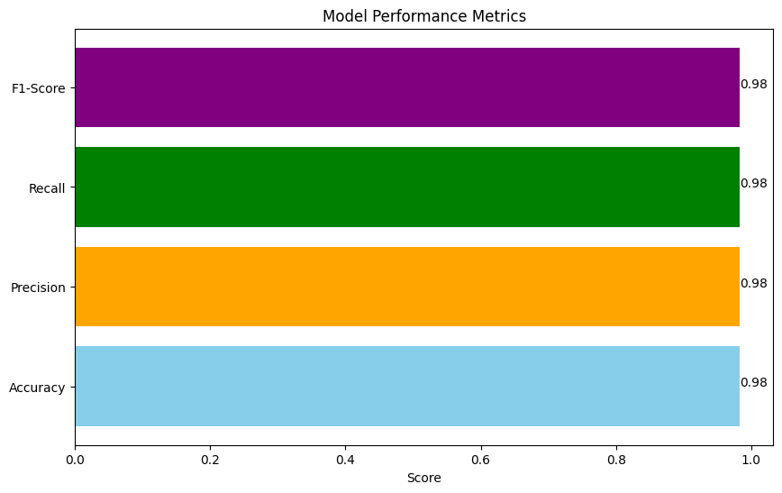

#### 🔍 **Analyse des résultats :**

Les métriques globales du modèle sont **excellentes**, avec des scores très élevés :

- **Accuracy :** 0.983 → Le modèle est précis à **98.3%**, ce qui est remarquable.
- **Precision :** 0.983 → Lorsqu'il prédit une intention de voyage, il se trompe **très rarement**.
- **Recall :** 0.983 → Il détecte correctement **presque toutes** les intentions de voyage.
- **F1-Score :** 0.983 → La balance entre précision et rappel est **quasi-parfaite**.

📌 **Conclusion :**  
Le modèle **généralise très bien** et atteint des performances presque parfaites sur les données de test.

## Matrice de confusion

La matrice de confusion compare les prédictions du modèle avec les étiquettes réelles :

- **Vrais positifs (TP)** : Cas positifs correctement prédits.
- **Vrais négatifs (TN)** : Cas négatifs correctement prédits.
- **Faux positifs (FP)** : Cas négatifs incorrectement prédits comme positifs.
- **Faux négatifs (FN)** : Cas positifs incorrectement prédits comme négatifs.

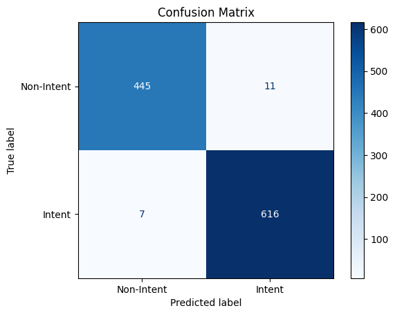

#### 🔍 **Analyse des résultats :**

✅ **Le modèle est donc extrêmement fiable et minimise au maximum les erreurs !**

## Courbe ROC

La courbe ROC illustre le compromis entre le taux de vrais positifs (**Recall**) et le taux de faux positifs à différents seuils :

- **Taux de vrais positifs (TPR)** : Proportion des vrais cas positifs correctement identifiés.
- **Taux de faux positifs (FPR)** : Proportion des cas négatifs incorrectement classés comme positifs.
- **AUC (Surface sous la courbe)** : Représente la capacité globale du modèle à discriminer entre classes. Une valeur proche de 1 indique de meilleures performances.

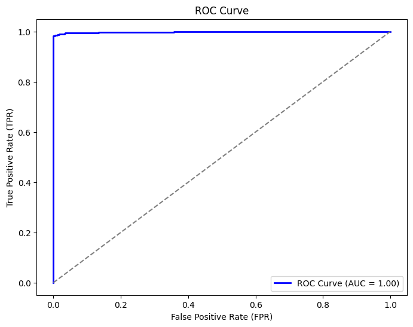

#### 🔍 **Analyse des résultats :**

La **courbe ROC** montre la capacité du modèle à discriminer entre les classes.

- **AUC = 0.998** → **Un score proche de 1 est idéal**, et ici nous avons **0.998**, ce qui est **excellent**.
- 📈 **La courbe monte directement à 0.98**, ce qui signifie que le modèle détecte très vite une grande partie des vrais positifs.
- 🚀 **Progression rapide vers 1 (0.998) ** : après ce premier pic, la courbe atteint **rapidement** le maximum, montrant une séparation **très nette** entre les classes.
- 📏 **Ligne stable proche du 1 sur 0.998** : une fois ce seuil atteint, la courbe **reste droite sur 1**, prouvant que le modèle **ne fait presque aucune erreur pour les scores élevés**.

📌 **Interprétation :**

- ✅ **Le modèle distingue très bien** les phrases qui parlent de voyage et celles qui n'en parlent pas.
- ✅ **Une montée immédiate à 0.98** signifie que les intentions de voyage sont détectées **dès les premiers seuils de probabilité**.
- ✅ **La ligne plate proche du 1 sur 0.998 ** confirme qu'au-delà d'un certain seuil, **toutes les prédictions sont correctes**.
- 🎯 **En conclusion :** La **quasi-perfection** du modèle est confirmée par cette courbe ROC, prouvant qu'il fait **très peu d'erreurs**.

## Distribution des scores de probabilité

Ce graphique montre la distribution des scores de probabilité pour chaque classe :

- **Non-Intention** : Scores pour les exemples classés comme "Non-Intention".
- **Intention** : Scores pour les exemples classés comme "Intention". Une bonne séparation entre les deux classes est souhaitable pour un modèle performant.

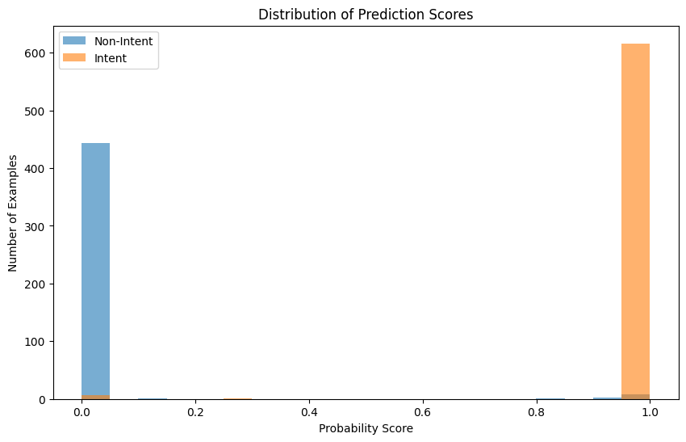

#### 🔍 **Analyse des résultats :**

Ce graphique montre la **répartition des probabilités** attribuées par le modèle.

📌 **Observations :**

- 🔹 Une **très grande barre bleue** à **0 de probabilité score** → **440 exemples classés avec certitude comme "Non-Intent"**.
- 🔹 Une **énorme barre orange** à **1 de probabilité score** → **600 exemples sont détectés avec certitude comme "Intent"**.
- 🔹 **Très peu d'exemples entre 0.1 et 0.9**, ce qui signifie que le modèle **n'est pas hésitant**.

✅ **Interprétation :**

- Le modèle fait des **prédictions tranchées** et **ne doute presque jamais**.
- **Il est sûr à 100% sur une immense majorité des cas.**
- **Seuls quelques exemples (~10) ont une probabilité moyenne (entre 0.8 et 0.9), montrant un modèle bien calibré.**